# Storm_Analysis

Joe Lee

1/3/2018

## Synopsis

In this report I aim to identify the event types that are most harmful to population health, and the event types that have the greatest economic consequences. I will be using the U.S. National Oceanic and Atmospheric Administration’s (NOAA) storm database.

## Data Loading and Processing

Load pertinent libraries. Download the data file and use read.csv to read it in.

```r
library(dplyr)
```

```r
library(ggplot2)
library(knitr)
fileUrl <-
        "https://d396qusza40orc.cloudfront.net/repdata%2Fdata%2FStormData.csv.bz2"
download.file(fileUrl, "repdata%2Fdata%2FStormData.csv.bz2")
data <- read.csv("./repdata%2Fdata%2FStormData.csv.bz2", header = TRUE,sep = ",")
```

After reading the data, check the dimensions.

```r
dim(data)
```

```
## [1] 902297     37
```

```r
head(data)
```

```
##   STATE__           BGN_DATE BGN_TIME TIME_ZONE COUNTY COUNTYNAME STATE
## 1       1  4/18/1950 0:00:00     0130       CST     97     MOBILE    AL
## 2       1  4/18/1950 0:00:00     0145       CST      3    BALDWIN    AL
## 3       1  2/20/1951 0:00:00     1600       CST     57    FAYETTE    AL
## 4       1   6/8/1951 0:00:00     0900       CST     89    MADISON    AL
## 5       1 11/15/1951 0:00:00     1500       CST     43    CULLMAN    AL
## 6       1 11/15/1951 0:00:00     2000       CST     77 LAUDERDALE    AL
##    EVTYPE BGN_RANGE BGN_AZI BGN_LOCATI END_DATE END_TIME COUNTY_END
## 1 TORNADO         0                                               0
## 2 TORNADO         0                                               0
## 3 TORNADO         0                                               0
## 4 TORNADO         0                                               0
## 5 TORNADO         0                                               0
## 6 TORNADO         0                                               0
##   COUNTYENDN END_RANGE END_AZI END_LOCATI LENGTH WIDTH F MAG FATALITIES
```

[output cut: 20 more lines]

```r
str(data)
```

```
## 'data.frame':    902297 obs. of  37 variables:
##  $ STATE__   : num  1 1 1 1 1 1 1 1 1 1 ...
##  $ BGN_DATE  : Factor w/ 16335 levels "1/1/1966 0:00:00",..: 6523 6523 4242 11116 2224 2224 2260 383 3980 3980 ...
##  $ BGN_TIME  : Factor w/ 3608 levels "00:00:00 AM",..: 272 287 2705 1683 2584 3186 242 1683 3186 3186 ...
##  $ TIME_ZONE : Factor w/ 22 levels "ADT","AKS","AST",..: 7 7 7 7 7 7 7 7 7 7 ...
##  $ COUNTY    : num  97 3 57 89 43 77 9 123 125 57 ...
##  $ COUNTYNAME: Factor w/ 29601 levels "","5NM E OF MACKINAC BRIDGE TO PRESQUE ISLE LT MI",..: 13513 1873 4598 10592 4372 10094 1973 23873 24418 4598 ...
##  $ STATE     : Factor w/ 72 levels "AK","AL","AM",..: 2 2 2 2 2 2 2 2 2 2 ...
##  $ EVTYPE    : Factor w/ 985 levels "   HIGH SURF ADVISORY",..: 834 834 834 834 834 834 834 834 834 834 ...
##  $ BGN_RANGE : num  0 0 0 0 0 0 0 0 0 0 ...
##  $ BGN_AZI   : Factor w/ 35 levels "","  N"," NW",..: 1 1 1 1 1 1 1 1 1 1 ...
##  $ BGN_LOCATI: Factor w/ 54429 levels ""," Christiansburg",..: 1 1 1 1 1 1 1 1 1 1 ...
##  $ END_DATE  : Factor w/ 6663 levels "","1/1/1993 0:00:00",..: 1 1 1 1 1 1 1 1 1 1 ...
##  $ END_TIME  : Factor w/ 3647 levels ""," 0900CST",..: 1 1 1 1 1 1 1 1 1 1 ...
##  $ COUNTY_END: num  0 0 0 0 0 0 0 0 0 0 ...
```

[output cut: 23 more lines]

### Determine storm event type harmful to population health

Across the United States, which types of events (as indicated in the 𝙴𝚅𝚃𝚈𝙿𝙴 variable) are most harmful with respect to population health?

The relevant columns of the data set were selected. First, summarize the total number of fatalities and injuries separately for each storm event type. Second, rank in descending order by number of fatalities by event type. Third, rank in descending order by number of injuries. Fourth, rank in descending order by fatalities then injuries. Modified the ranking to improve plotting. Finally, show top ten of the last ranking.

```r
data2 <- select(data, EVTYPE,FATALITIES,INJURIES,PROPDMG,PROPDMGEXP,
                CROPDMG, CROPDMGEXP)
data3 <- data2 %>% group_by(EVTYPE) %>% summarize(sum.fatalities = sum(FATALITIES),sum.injuries = sum(INJURIES))
data4 <- data3 %>% arrange(desc(sum.fatalities))
data5 <- data3 %>% arrange(desc(sum.injuries))
data6 <- data3 %>% arrange(desc(sum.fatalities),desc(sum.injuries))
data6$EVTYPE <- factor(data6$EVTYPE, levels = data6$EVTYPE[order(data6$sum.fatalities,decreasing=T)])
data7 <- head(data6,10)
data7
```

```
## # A tibble: 10 x 3
##            EVTYPE sum.fatalities sum.injuries
##            <fctr>          <dbl>        <dbl>
##  1        TORNADO           5633        91346
##  2 EXCESSIVE HEAT           1903         6525
##  3    FLASH FLOOD            978         1777
##  4           HEAT            937         2100
##  5      LIGHTNING            816         5230
##  6      TSTM WIND            504         6957
##  7          FLOOD            470         6789
##  8    RIP CURRENT            368          232
##  9      HIGH WIND            248         1137
## 10      AVALANCHE            224          170
```

### Determine storm event type with the greatest economic consequences

‘Economic consequences’ was interpreted as the sum of property and crop damage due to the storm event.

The expontent values of the PROPDMGEXP and CROPDMGEXP columns signifies magnitude include “K” for thousands, “M” for millions, and “B” for billions.

Since the NOAA website is not explicit on how to handle the rest of the exponent values of the PROPDMGEXP and CROPDMGEXP columns of the database, the following website was used to determine possible values.

Reference: https://rstudio-pubs-static.s3.amazonaws.com/58957_37b6723ee52b455990e149edde45e5b6.html

#### Possible values of CROPDMGEXP and PROPDMGEXP and their converted values

- H,h,K,k,M,m,B,b,+,-,?,0,1,2,3,4,5,6,7,8, and blank-character
- H,h = hundreds = 100
- K,k = kilos = thousands = 1,000
- M,m = millions = 1,000,000
- B,b = billions = 1,000,000,000
- (+) = 1
- (-) = 0
- (?) = 0
- black/empty character (“”) = 0
- numeric 0..8 = 10

Convert proper values and calculate total damage including property and crops. Then show top 10 storm event types in descending order by damage.

```r
storm <- select(data2, -c(FATALITIES,INJURIES))
storm1<-storm
storm1$PROPDMGEXP <- as.character(storm1$PROPDMGEXP)
storm1$PROPDMGEXP <- gsub("[0-8]","10",storm1$PROPDMGEXP)
storm1$PROPDMGEXP <- gsub("[Hh]","100",storm1$PROPDMGEXP)
storm1$PROPDMGEXP <- gsub("[Kk]","1000",storm1$PROPDMGEXP)
storm1$PROPDMGEXP <- gsub("[Mm]","1000000",storm1$PROPDMGEXP)
storm1$PROPDMGEXP <- gsub("[Bb]","1000000000",storm1$PROPDMGEXP)
storm1$PROPDMGEXP <- gsub("[+]","1",storm1$PROPDMGEXP)
storm1$PROPDMGEXP <- gsub("[-|?]","0",storm1$PROPDMGEXP)
storm1$PROPDMGEXP <- as.numeric(storm1$PROPDMGEXP)
storm1$PROPDMGEXP[is.na(storm1$PROPDMGEXP)] <- 0

storm1$CROPDMGEXP <- as.character(storm1$CROPDMGEXP)
storm1$CROPDMGEXP <- gsub("[0-8]","10",storm1$CROPDMGEXP)
storm1$CROPDMGEXP <- gsub("[Hh]","100",storm1$CROPDMGEXP)
storm1$CROPDMGEXP <- gsub("[Kk]","1000",storm1$CROPDMGEXP)
storm1$CROPDMGEXP <- gsub("[Mm]","1000000",storm1$CROPDMGEXP)
storm1$CROPDMGEXP <- gsub("[Bb]","1000000000",storm1$CROPDMGEXP)
storm1$CROPDMGEXP <- gsub("[+]","1",storm1$CROPDMGEXP)
storm1$CROPDMGEXP <- gsub("[-|?]","0",storm1$CROPDMGEXP)
storm1$CROPDMGEXP <- as.numeric(storm1$CROPDMGEXP)
storm1$CROPDMGEXP[is.na(storm1$CROPDMGEXP)] <- 0

storm2 <- mutate(storm1,damagevalue=(PROPDMG*PROPDMGEXP)+(CROPDMG*CROPDMGEXP))
storm3 <- storm2 %>% group_by(EVTYPE) %>% summarize(value = sum(damagevalue)) %>%
    arrange(desc(value))
storm3$EVTYPE <- factor(storm3$EVTYPE, levels = storm3$EVTYPE[order(storm3$value,decreasing=T)])
storm4 <- head(storm3,10)
head(storm3,10)
```

```
## # A tibble: 10 x 2
##               EVTYPE        value
##               <fctr>        <dbl>
##  1             FLOOD 150319678250
##  2 HURRICANE/TYPHOON  71913712800
##  3           TORNADO  57352117607
##  4       STORM SURGE  43323541000
##  5              HAIL  18758224527
##  6       FLASH FLOOD  17562132111
##  7           DROUGHT  15018672000
##  8         HURRICANE  14610229010
##  9       RIVER FLOOD  10148404500
## 10         ICE STORM   8967041810
```

## Results

### Plot of event types most harmful to population health

This plot shows the top 10 most harmful storm event types to population health in descending order by fatalities then by injuries.

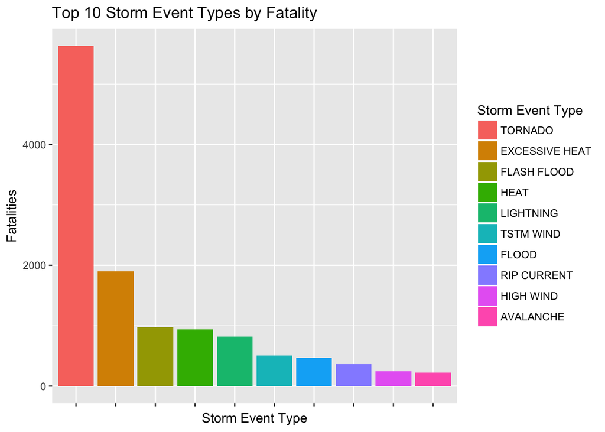

```r
ggplot(data7, aes(EVTYPE,sum.fatalities,fill=EVTYPE))+
  geom_bar(stat="identity")+
  labs(title="Top 10 Storm Event Types by Fatality",
    x="Storm Event Type",
    y="Fatalities")+
  theme(axis.text.x=element_blank())+
  guides(fill=guide_legend(title="Storm Event Type"))
```

### Plot of event types with the greatest economic consequences

This plot shows the top 10 storm event types with the greatest economic consequences in descending order. Economic consquences was measured as the sum of property and crop damage.

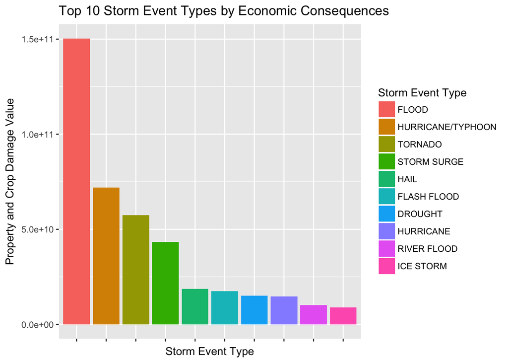

```r
ggplot(storm4, aes(EVTYPE,value,fill=EVTYPE))+
  geom_bar(stat="identity")+
  labs(title="Top 10 Storm Event Types by Economic Consequences",
    x="Storm Event Type",
    y="Property and Crop Damage Value")+
  theme(axis.text.x=element_blank())+
  guides(fill=guide_legend(title="Storm Event Type"))
```